# Project Proposal

## 1. code to read data

We are using the API to download the data. First, we download the kaggle in Linux and use this code to download the dataset. pip install kaggle

```r
#kaggle datasets download -d danilpan/yellow-new-york-taxi
```

```r
YellowText = read.csv("/Users/yi/Desktop/MyRCode/yellow_tripdata_2010-12.csv")
head(YellowText)
```

```
##   vendor_id     pickup_datetime    dropoff_datetime passenger_count
## 1       VTS 2010-12-03 00:22:00 2010-12-03 00:30:00               1
## 2       VTS 2010-12-05 01:37:00 2010-12-05 01:41:00               1
## 3       VTS 2010-12-01 12:14:00 2010-12-01 12:36:00               2
## 4       VTS 2010-12-05 06:44:00 2010-12-05 06:58:00               1
## 5       VTS 2010-12-03 08:28:00 2010-12-03 08:51:00               1
## 6       VTS 2010-12-05 03:23:00 2010-12-05 03:32:00               1
##   trip_distance pickup_longitude pickup_latitude rate_code store_and_fwd_flag
## 1          1.99        -73.98219        40.76809         1
## 2          0.78        -73.98640        40.72962         1
## 3          2.06        -73.99694        40.73719         1
## 4          5.03        -73.98932        40.74820         1
## 5          2.61        -73.95514        40.76533         1
## 6          2.34        -74.00689        40.74421         1
##   dropoff_longitude dropoff_latitude payment_type fare_amount surcharge mta_tax
## 1         -73.99622         40.74306          CSH         7.3       0.5     0.5
## 2         -73.98122         40.73636          CRD         4.1       0.5     0.5
## 3         -73.97543         40.75727          CSH        11.7       0.0     0.5
## 4         -73.92161         40.74397          CSH        13.3       0.0     0.5
## 5         -73.98457         40.74451          CSH        12.5       0.0     0.5
## 6         -73.97389         40.74340          CRD         8.1       0.5     0.5
##   tip_amount tolls_amount total_amount
## 1          0            0          8.3
## 2          1            0          6.1
## 3          0            0         12.2
## 4          0            0         13.8
## 5          0            0         13.0
## 6          0            0          9.1
```

## 2. Descriptions of the variables

```r
sample_ID = sample(c(1:dim(YellowText)[1]), 1000000)
YellowText_sample =  YellowText[sample_ID,]
```

There are 18 variables in total in the Yellow New York Taxi dataset. We will use four of them including number of passengers, total distance as the prediction variables to predict the desired outcome variable tip amount  
Passenger_Count: Number of passengers in the trip.  
Trip_Distance: The total distance of the trip in miles.  
Payment_Type: The payment method passengers choose to pay.  
Fare_Amt: Amount of taxi fare of the trip  
Tip_Amt: Amount of tip of the trip

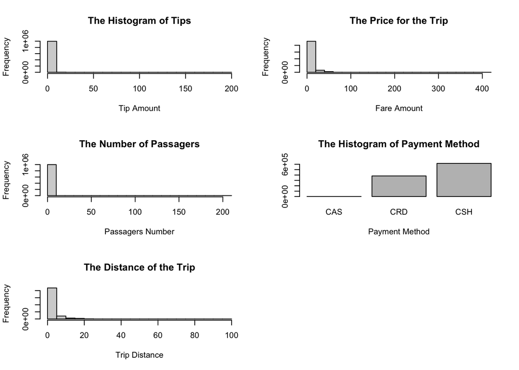

```r
par(mfrow = c(3,2))
hist(YellowText_sample$tip_amount, main = "The Histogram of Tips", xlab = "Tip Amount")
hist(YellowText_sample$fare_amount, main = "The Price for the Trip", xlab = "Fare Amount")
hist(YellowText_sample$passenger_count, main = "The Number of Passagers", xlab = "Passagers Number")
barplot(table(YellowText_sample$payment_type), main = "The Histogram of Payment Method", xlab = "Payment Method")
hist(YellowText_sample$trip_distance, main = "The Distance of the Trip", xlab = "Trip Distance")
```

## 3. Statistical Methods

Huber loss regression function. we are applying the huber loss function to construct the statistics model similar to Multiple Linear Regression but more accurate while we can just lower the impact of the outliers to our statistical model.

## 4. computational steps you will use

First, collect data and clean data. The taxi data is between 2009 and 2012. Each year has 12 months of data. We will combine the same year data, and extract columns Passenger_Count, Trip_Distance, Payment_Type, Fare_Amt and Tip_Amt. Then collect yearly data into a single file. There will be 2009, 2010, 2011, 2012 and overall data.

Second, build the multiple linear regression model. Tip_Amt is a dependent variable. Passenger_Count, Trip_Distance, Payment_Type and Fare_Amt are explanatory variables.

## 5. Link to Github repository

https://github.com/YiM2001/Stat479FinalProject